# Risk Factor Analysis

## Outcome Variable

**Outcome Variable:** stunted

## Predictor Variables

**Intervention Variable:** perdiar24

**Adjustment Set:**

unadjusted

## Stratifying Variables

The analysis was stratified on these variable(s):

- agecat
- studyid
- country

## Data Summary

| agecat | studyid | country | perdiar24 | stunted | n_cell | n | outcome_variable |
| --- | --- | --- | --- | --- | --- | --- | --- |
| Birth | ki0047075b-MAL-ED | BANGLADESH | 0% | 0 | 13 | 231 | stunted |
| Birth | ki0047075b-MAL-ED | BANGLADESH | 0% | 1 | 5 | 231 | stunted |
| Birth | ki0047075b-MAL-ED | BANGLADESH | (0%, 5%] | 0 | 112 | 231 | stunted |
| Birth | ki0047075b-MAL-ED | BANGLADESH | (0%, 5%] | 1 | 19 | 231 | stunted |
| Birth | ki0047075b-MAL-ED | BANGLADESH | >5% | 0 | 62 | 231 | stunted |
| Birth | ki0047075b-MAL-ED | BANGLADESH | >5% | 1 | 20 | 231 | stunted |
| Birth | ki0047075b-MAL-ED | BRAZIL | 0% | 0 | 31 | 65 | stunted |
| Birth | ki0047075b-MAL-ED | BRAZIL | 0% | 1 | 3 | 65 | stunted |
| Birth | ki0047075b-MAL-ED | BRAZIL | (0%, 5%] | 0 | 23 | 65 | stunted |
| Birth | ki0047075b-MAL-ED | BRAZIL | (0%, 5%] | 1 | 6 | 65 | stunted |
| Birth | ki0047075b-MAL-ED | BRAZIL | >5% | 0 | 2 | 65 | stunted |
| Birth | ki0047075b-MAL-ED | BRAZIL | >5% | 1 | 0 | 65 | stunted |
| Birth | ki0047075b-MAL-ED | INDIA | 0% | 0 | 4 | 47 | stunted |
| Birth | ki0047075b-MAL-ED | INDIA | 0% | 1 | 1 | 47 | stunted |
| Birth | ki0047075b-MAL-ED | INDIA | (0%, 5%] | 0 | 27 | 47 | stunted |
| Birth | ki0047075b-MAL-ED | INDIA | (0%, 5%] | 1 | 6 | 47 | stunted |
| Birth | ki0047075b-MAL-ED | INDIA | >5% | 0 | 6 | 47 | stunted |
| Birth | ki0047075b-MAL-ED | INDIA | >5% | 1 | 3 | 47 | stunted |
| Birth | ki0047075b-MAL-ED | NEPAL | 0% | 0 | 2 | 27 | stunted |
| Birth | ki0047075b-MAL-ED | NEPAL | 0% | 1 | 0 | 27 | stunted |
| Birth | ki0047075b-MAL-ED | NEPAL | (0%, 5%] | 0 | 19 | 27 | stunted |
| Birth | ki0047075b-MAL-ED | NEPAL | (0%, 5%] | 1 | 0 | 27 | stunted |
| Birth | ki0047075b-MAL-ED | NEPAL | >5% | 0 | 4 | 27 | stunted |
| Birth | ki0047075b-MAL-ED | NEPAL | >5% | 1 | 2 | 27 | stunted |
| Birth | ki0047075b-MAL-ED | PERU | 0% | 0 | 21 | 233 | stunted |
| Birth | ki0047075b-MAL-ED | PERU | 0% | 1 | 0 | 233 | stunted |
| Birth | ki0047075b-MAL-ED | PERU | (0%, 5%] | 0 | 78 | 233 | stunted |
| Birth | ki0047075b-MAL-ED | PERU | (0%, 5%] | 1 | 11 | 233 | stunted |
| Birth | ki0047075b-MAL-ED | PERU | >5% | 0 | 108 | 233 | stunted |
| Birth | ki0047075b-MAL-ED | PERU | >5% | 1 | 15 | 233 | stunted |

[output cut: 234 more lines]

The following strata were considered:

- agecat: 24 months, studyid: ki0047075b-MAL-ED, country: BANGLADESH
- agecat: 24 months, studyid: ki0047075b-MAL-ED, country: BRAZIL
- agecat: 24 months, studyid: ki0047075b-MAL-ED, country: INDIA
- agecat: 24 months, studyid: ki0047075b-MAL-ED, country: NEPAL
- agecat: 24 months, studyid: ki0047075b-MAL-ED, country: PERU
- agecat: 24 months, studyid: ki0047075b-MAL-ED, country: SOUTH AFRICA
- agecat: 24 months, studyid: ki0047075b-MAL-ED, country: TANZANIA, UNITED REPUBLIC OF
- agecat: 24 months, studyid: ki1000109-EE, country: PAKISTAN
- agecat: 24 months, studyid: ki1017093-NIH-Birth, country: BANGLADESH
- agecat: 24 months, studyid: ki1017093b-PROVIDE, country: BANGLADESH
- agecat: 24 months, studyid: ki1017093c-NIH-Crypto, country: BANGLADESH
- agecat: 24 months, studyid: ki1114097-CMIN, country: BANGLADESH
- agecat: 24 months, studyid: ki1114097-CONTENT, country: PERU
- agecat: 24 months, studyid: kiGH5241-JiVitA-4, country: BANGLADESH
- agecat: 6 months, studyid: ki0047075b-MAL-ED, country: BANGLADESH
- agecat: 6 months, studyid: ki0047075b-MAL-ED, country: BRAZIL
- agecat: 6 months, studyid: ki0047075b-MAL-ED, country: INDIA
- agecat: 6 months, studyid: ki0047075b-MAL-ED, country: NEPAL
- agecat: 6 months, studyid: ki0047075b-MAL-ED, country: PERU
- agecat: 6 months, studyid: ki0047075b-MAL-ED, country: SOUTH AFRICA
- agecat: 6 months, studyid: ki0047075b-MAL-ED, country: TANZANIA, UNITED REPUBLIC OF
- agecat: 6 months, studyid: ki1000109-EE, country: PAKISTAN
- agecat: 6 months, studyid: ki1000304b-SAS-FoodSuppl, country: INDIA
- agecat: 6 months, studyid: ki1017093-NIH-Birth, country: BANGLADESH
- agecat: 6 months, studyid: ki1017093b-PROVIDE, country: BANGLADESH
- agecat: 6 months, studyid: ki1017093c-NIH-Crypto, country: BANGLADESH
- agecat: 6 months, studyid: ki1112895-Guatemala BSC, country: GUATEMALA
- agecat: 6 months, studyid: ki1114097-CMIN, country: BANGLADESH
- agecat: 6 months, studyid: ki1114097-CONTENT, country: PERU
- agecat: 6 months, studyid: kiGH5241-JiVitA-4, country: BANGLADESH
- agecat: Birth, studyid: ki0047075b-MAL-ED, country: BANGLADESH
- agecat: Birth, studyid: ki0047075b-MAL-ED, country: BRAZIL
- agecat: Birth, studyid: ki0047075b-MAL-ED, country: INDIA
- agecat: Birth, studyid: ki0047075b-MAL-ED, country: NEPAL
- agecat: Birth, studyid: ki0047075b-MAL-ED, country: PERU
- agecat: Birth, studyid: ki0047075b-MAL-ED, country: SOUTH AFRICA
- agecat: Birth, studyid: ki0047075b-MAL-ED, country: TANZANIA, UNITED REPUBLIC OF
- agecat: Birth, studyid: ki1000109-EE, country: PAKISTAN
- agecat: Birth, studyid: ki1017093-NIH-Birth, country: BANGLADESH
- agecat: Birth, studyid: ki1017093b-PROVIDE, country: BANGLADESH
- agecat: Birth, studyid: ki1017093c-NIH-Crypto, country: BANGLADESH
- agecat: Birth, studyid: ki1114097-CMIN, country: BANGLADESH
- agecat: Birth, studyid: ki1114097-CONTENT, country: PERU
- agecat: Birth, studyid: kiGH5241-JiVitA-4, country: BANGLADESH

### Dropped Strata

Some strata were dropped due to rare outcomes:

- agecat: Birth, studyid: ki0047075b-MAL-ED, country: BRAZIL
- agecat: Birth, studyid: ki0047075b-MAL-ED, country: INDIA
- agecat: Birth, studyid: ki0047075b-MAL-ED, country: NEPAL
- agecat: Birth, studyid: ki0047075b-MAL-ED, country: PERU
- agecat: Birth, studyid: ki0047075b-MAL-ED, country: SOUTH AFRICA
- agecat: Birth, studyid: ki0047075b-MAL-ED, country: TANZANIA, UNITED REPUBLIC OF
- agecat: Birth, studyid: ki1000109-EE, country: PAKISTAN
- agecat: Birth, studyid: ki1017093b-PROVIDE, country: BANGLADESH
- agecat: Birth, studyid: ki1114097-CMIN, country: BANGLADESH
- agecat: Birth, studyid: ki1114097-CONTENT, country: PERU
- agecat: 6 months, studyid: ki0047075b-MAL-ED, country: BANGLADESH
- agecat: 6 months, studyid: ki0047075b-MAL-ED, country: BRAZIL
- agecat: 6 months, studyid: ki0047075b-MAL-ED, country: INDIA
- agecat: 6 months, studyid: ki0047075b-MAL-ED, country: NEPAL
- agecat: 6 months, studyid: ki0047075b-MAL-ED, country: PERU
- agecat: 6 months, studyid: ki0047075b-MAL-ED, country: SOUTH AFRICA
- agecat: 6 months, studyid: ki0047075b-MAL-ED, country: TANZANIA, UNITED REPUBLIC OF
- agecat: 6 months, studyid: ki1000109-EE, country: PAKISTAN
- agecat: 6 months, studyid: ki1017093b-PROVIDE, country: BANGLADESH
- agecat: 6 months, studyid: ki1114097-CMIN, country: BANGLADESH
- agecat: 6 months, studyid: ki1114097-CONTENT, country: PERU
- agecat: 24 months, studyid: ki0047075b-MAL-ED, country: BANGLADESH
- agecat: 24 months, studyid: ki0047075b-MAL-ED, country: BRAZIL
- agecat: 24 months, studyid: ki0047075b-MAL-ED, country: INDIA
- agecat: 24 months, studyid: ki0047075b-MAL-ED, country: NEPAL
- agecat: 24 months, studyid: ki0047075b-MAL-ED, country: PERU
- agecat: 24 months, studyid: ki0047075b-MAL-ED, country: SOUTH AFRICA
- agecat: 24 months, studyid: ki0047075b-MAL-ED, country: TANZANIA, UNITED REPUBLIC OF
- agecat: 24 months, studyid: ki1000109-EE, country: PAKISTAN
- agecat: 24 months, studyid: ki1017093-NIH-Birth, country: BANGLADESH
- agecat: 24 months, studyid: ki1017093b-PROVIDE, country: BANGLADESH
- agecat: 24 months, studyid: ki1114097-CMIN, country: BANGLADESH
- agecat: 24 months, studyid: ki1114097-CONTENT, country: PERU

## Methods Detail

We’re interested in the causal parameters $E[Y_a]$ for all values of $a \in \mathcal{A}$. These parameters represent the mean outcome if, possibly contrary to fact, we intervened to set all units to have $A=a$. Under the randomization and positivity assumptions, these are identified by the statistical parameters $\psi_a=E_W[E_{Y|A,W}(Y|A=a,W)]$. In addition, we’re interested in the mean of $Y$, $E[Y]$ under no intervention (the observed mean). We will estimate these parameters by using SuperLearner to fit the relevant likelihood factors – $E_{Y|A,W}(Y|A=a,W)$ and $p(A=a|W)$, and then updating our likelihood fit using a joint TMLE.

For unadjusted analyses ($W=\{\}$), initial likelihoods were estimated using Lrnr_glm to estimate the simple $E(Y|A)$ and Lrnr_mean to estimate $p(A)$. For adjusted analyses, a small library containing Lrnr_glmnet, Lrnr_xgboost, and Lrnr_mean was used.

Having estimated these parameters, we will then use the delta method to estimate relative risks and attributable risks relative to a prespecified baseline level of $A$.

# Results Detail

## Results Plots

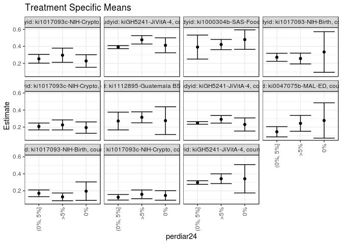

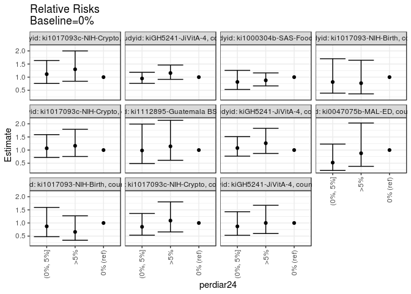

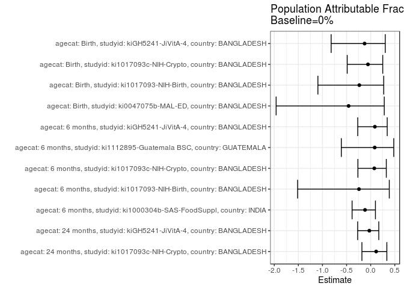

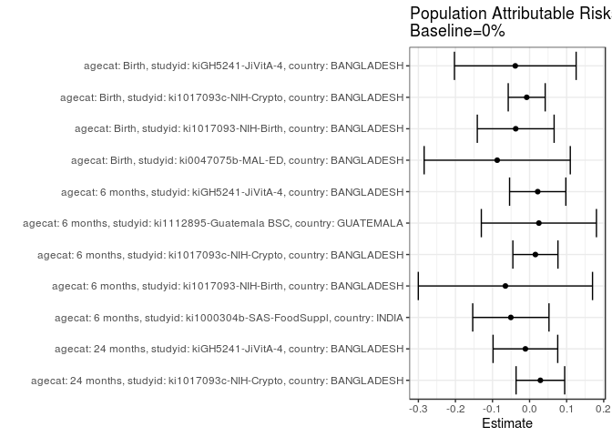

## Results Table

### Parameter: TSM

| agecat | studyid | country | intervention_level | baseline_level | estimate | ci_lower | ci_upper |
| --- | --- | --- | --- | --- | --- | --- | --- |
| Birth | ki0047075b-MAL-ED | BANGLADESH | 0% | NA | 0.2777778 | 0.0704115 | 0.4851440 |
| Birth | ki0047075b-MAL-ED | BANGLADESH | (0%, 5%] | NA | 0.1450382 | 0.0846059 | 0.2054705 |
| Birth | ki0047075b-MAL-ED | BANGLADESH | >5% | NA | 0.2439024 | 0.1507530 | 0.3370519 |
| Birth | ki1017093-NIH-Birth | BANGLADESH | 0% | NA | 0.1960784 | 0.0870238 | 0.3051330 |
| Birth | ki1017093-NIH-Birth | BANGLADESH | (0%, 5%] | NA | 0.1710145 | 0.1312507 | 0.2107783 |
| Birth | ki1017093-NIH-Birth | BANGLADESH | >5% | NA | 0.1291866 | 0.0836767 | 0.1746965 |
| Birth | ki1017093c-NIH-Crypto | BANGLADESH | 0% | NA | 0.1456954 | 0.0893853 | 0.2020054 |
| Birth | ki1017093c-NIH-Crypto | BANGLADESH | (0%, 5%] | NA | 0.1243523 | 0.0914109 | 0.1572938 |
| Birth | ki1017093c-NIH-Crypto | BANGLADESH | >5% | NA | 0.1589744 | 0.1076178 | 0.2103309 |
| Birth | kiGH5241-JiVitA-4 | BANGLADESH | 0% | NA | 0.3421053 | 0.1751112 | 0.5090994 |
| Birth | kiGH5241-JiVitA-4 | BANGLADESH | (0%, 5%] | NA | 0.2976725 | 0.2765478 | 0.3187973 |
| Birth | kiGH5241-JiVitA-4 | BANGLADESH | >5% | NA | 0.3422819 | 0.2846602 | 0.3999035 |
| 6 months | ki1000304b-SAS-FoodSuppl | INDIA | 0% | NA | 0.4794521 | 0.3646996 | 0.5942045 |
| 6 months | ki1000304b-SAS-FoodSuppl | INDIA | (0%, 5%] | NA | 0.3913043 | 0.2500835 | 0.5325252 |
| 6 months | ki1000304b-SAS-FoodSuppl | INDIA | >5% | NA | 0.4214559 | 0.3614707 | 0.4814412 |
| 6 months | ki1017093-NIH-Birth | BANGLADESH | 0% | NA | 0.3333333 | 0.0945517 | 0.5721150 |
| 6 months | ki1017093-NIH-Birth | BANGLADESH | (0%, 5%] | NA | 0.2713864 | 0.2240064 | 0.3187665 |
| 6 months | ki1017093-NIH-Birth | BANGLADESH | >5% | NA | 0.2568306 | 0.1934736 | 0.3201876 |
| 6 months | ki1017093c-NIH-Crypto | BANGLADESH | 0% | NA | 0.1940299 | 0.1270270 | 0.2610327 |
| 6 months | ki1017093c-NIH-Crypto | BANGLADESH | (0%, 5%] | NA | 0.2072539 | 0.1667891 | 0.2477186 |
| 6 months | ki1017093c-NIH-Crypto | BANGLADESH | >5% | NA | 0.2256410 | 0.1669306 | 0.2843514 |
| 6 months | ki1112895-Guatemala BSC | GUATEMALA | 0% | NA | 0.2758621 | 0.1129200 | 0.4388041 |
| 6 months | ki1112895-Guatemala BSC | GUATEMALA | (0%, 5%] | NA | 0.2714286 | 0.1670791 | 0.3757781 |
| 6 months | ki1112895-Guatemala BSC | GUATEMALA | >5% | NA | 0.3150000 | 0.2505146 | 0.3794854 |
| 6 months | kiGH5241-JiVitA-4 | BANGLADESH | 0% | NA | 0.2307692 | 0.1536707 | 0.3078678 |
| 6 months | kiGH5241-JiVitA-4 | BANGLADESH | (0%, 5%] | NA | 0.2487359 | 0.2334511 | 0.2640206 |
| 6 months | kiGH5241-JiVitA-4 | BANGLADESH | >5% | NA | 0.2911877 | 0.2464139 | 0.3359616 |
| 24 months | ki1017093c-NIH-Crypto | BANGLADESH | 0% | NA | 0.2276423 | 0.1534679 | 0.3018167 |
| 24 months | ki1017093c-NIH-Crypto | BANGLADESH | (0%, 5%] | NA | 0.2536232 | 0.2022437 | 0.3050027 |
| 24 months | ki1017093c-NIH-Crypto | BANGLADESH | >5% | NA | 0.2956522 | 0.2121676 | 0.3791367 |
| 24 months | kiGH5241-JiVitA-4 | BANGLADESH | 0% | NA | 0.4121212 | 0.3242230 | 0.5000194 |
| 24 months | kiGH5241-JiVitA-4 | BANGLADESH | (0%, 5%] | NA | 0.3913043 | 0.3732084 | 0.4094003 |
| 24 months | kiGH5241-JiVitA-4 | BANGLADESH | >5% | NA | 0.4766734 | 0.4275219 | 0.5258250 |

### Parameter: E(Y)

| agecat | studyid | country | intervention_level | baseline_level | estimate | ci_lower | ci_upper |
| --- | --- | --- | --- | --- | --- | --- | --- |
| Birth | ki0047075b-MAL-ED | BANGLADESH | NA | NA | 0.1904762 | 0.1397281 | 0.2412242 |
| Birth | ki1017093-NIH-Birth | BANGLADESH | NA | NA | 0.1586777 | 0.1295391 | 0.1878163 |
| Birth | ki1017093c-NIH-Crypto | BANGLADESH | NA | NA | 0.1379781 | 0.1129774 | 0.1629789 |
| Birth | kiGH5241-JiVitA-4 | BANGLADESH | NA | NA | 0.3035778 | 0.2836422 | 0.3235133 |
| 6 months | ki1000304b-SAS-FoodSuppl | INDIA | NA | NA | 0.4289474 | 0.3791199 | 0.4787748 |
| 6 months | ki1017093-NIH-Birth | BANGLADESH | NA | NA | 0.2681564 | 0.2306532 | 0.3056597 |
| 6 months | ki1017093c-NIH-Crypto | BANGLADESH | NA | NA | 0.2097902 | 0.1799252 | 0.2396552 |
| 6 months | ki1112895-Guatemala BSC | GUATEMALA | NA | NA | 0.3010033 | 0.2489243 | 0.3530824 |
| 6 months | kiGH5241-JiVitA-4 | BANGLADESH | NA | NA | 0.2527427 | 0.2386864 | 0.2667990 |
| 24 months | ki1017093c-NIH-Crypto | BANGLADESH | NA | NA | 0.2568093 | 0.2190047 | 0.2946140 |
| 24 months | kiGH5241-JiVitA-4 | BANGLADESH | NA | NA | 0.4008838 | 0.3839145 | 0.4178532 |

### Parameter: RR

| agecat | studyid | country | intervention_level | baseline_level | estimate | ci_lower | ci_upper |
| --- | --- | --- | --- | --- | --- | --- | --- |
| Birth | ki0047075b-MAL-ED | BANGLADESH | 0% | 0% | 1.0000000 | 1.0000000 | 1.000000 |
| Birth | ki0047075b-MAL-ED | BANGLADESH | (0%, 5%] | 0% | 0.5221374 | 0.2220726 | 1.227650 |
| Birth | ki0047075b-MAL-ED | BANGLADESH | >5% | 0% | 0.8780488 | 0.3796172 | 2.030913 |
| Birth | ki1017093-NIH-Birth | BANGLADESH | 0% | 0% | 1.0000000 | 1.0000000 | 1.000000 |
| Birth | ki1017093-NIH-Birth | BANGLADESH | (0%, 5%] | 0% | 0.8721739 | 0.4773086 | 1.593701 |
| Birth | ki1017093-NIH-Birth | BANGLADESH | >5% | 0% | 0.6588517 | 0.3410879 | 1.272650 |
| Birth | ki1017093c-NIH-Crypto | BANGLADESH | 0% | 0% | 1.0000000 | 1.0000000 | 1.000000 |
| Birth | ki1017093c-NIH-Crypto | BANGLADESH | (0%, 5%] | 0% | 0.8535092 | 0.5342130 | 1.363647 |
| Birth | ki1017093c-NIH-Crypto | BANGLADESH | >5% | 0% | 1.0911422 | 0.6593521 | 1.805699 |
| Birth | kiGH5241-JiVitA-4 | BANGLADESH | 0% | 0% | 1.0000000 | 1.0000000 | 1.000000 |
| Birth | kiGH5241-JiVitA-4 | BANGLADESH | (0%, 5%] | 0% | 0.8701197 | 0.5301150 | 1.428196 |
| Birth | kiGH5241-JiVitA-4 | BANGLADESH | >5% | 0% | 1.0005163 | 0.5979700 | 1.674052 |
| 6 months | ki1000304b-SAS-FoodSuppl | INDIA | 0% | 0% | 1.0000000 | 1.0000000 | 1.000000 |
| 6 months | ki1000304b-SAS-FoodSuppl | INDIA | (0%, 5%] | 0% | 0.8161491 | 0.5292963 | 1.258462 |
| 6 months | ki1000304b-SAS-FoodSuppl | INDIA | >5% | 0% | 0.8790367 | 0.6653838 | 1.161293 |
| 6 months | ki1017093-NIH-Birth | BANGLADESH | 0% | 0% | 1.0000000 | 1.0000000 | 1.000000 |
| 6 months | ki1017093-NIH-Birth | BANGLADESH | (0%, 5%] | 0% | 0.8141593 | 0.3894920 | 1.701846 |
| 6 months | ki1017093-NIH-Birth | BANGLADESH | >5% | 0% | 0.7704918 | 0.3611877 | 1.643626 |
| 6 months | ki1017093c-NIH-Crypto | BANGLADESH | 0% | 0% | 1.0000000 | 1.0000000 | 1.000000 |
| 6 months | ki1017093c-NIH-Crypto | BANGLADESH | (0%, 5%] | 0% | 1.0681546 | 0.7183756 | 1.588242 |
| 6 months | ki1017093c-NIH-Crypto | BANGLADESH | >5% | 0% | 1.1629191 | 0.7546947 | 1.791958 |
| 6 months | ki1112895-Guatemala BSC | GUATEMALA | 0% | 0% | 1.0000000 | 1.0000000 | 1.000000 |
| 6 months | ki1112895-Guatemala BSC | GUATEMALA | (0%, 5%] | 0% | 0.9839286 | 0.4862853 | 1.990838 |
| 6 months | ki1112895-Guatemala BSC | GUATEMALA | >5% | 0% | 1.1418750 | 0.6111193 | 2.133591 |
| 6 months | kiGH5241-JiVitA-4 | BANGLADESH | 0% | 0% | 1.0000000 | 1.0000000 | 1.000000 |
| 6 months | kiGH5241-JiVitA-4 | BANGLADESH | (0%, 5%] | 0% | 1.0778554 | 0.7674472 | 1.513814 |
| 6 months | kiGH5241-JiVitA-4 | BANGLADESH | >5% | 0% | 1.2618135 | 0.8706751 | 1.828665 |
| 24 months | ki1017093c-NIH-Crypto | BANGLADESH | 0% | 0% | 1.0000000 | 1.0000000 | 1.000000 |
| 24 months | ki1017093c-NIH-Crypto | BANGLADESH | (0%, 5%] | 0% | 1.1141304 | 0.7591128 | 1.635181 |
| 24 months | ki1017093c-NIH-Crypto | BANGLADESH | >5% | 0% | 1.2987578 | 0.8438680 | 1.998857 |
| 24 months | kiGH5241-JiVitA-4 | BANGLADESH | 0% | 0% | 1.0000000 | 1.0000000 | 1.000000 |
| 24 months | kiGH5241-JiVitA-4 | BANGLADESH | (0%, 5%] | 0% | 0.9494885 | 0.7612818 | 1.184224 |
| 24 months | kiGH5241-JiVitA-4 | BANGLADESH | >5% | 0% | 1.1566341 | 0.9152189 | 1.461729 |

### Parameter: PAR

| agecat | studyid | country | intervention_level | baseline_level | estimate | ci_lower | ci_upper |
| --- | --- | --- | --- | --- | --- | --- | --- |
| Birth | ki0047075b-MAL-ED | BANGLADESH | 0% | NA | -0.0873016 | -0.2844683 | 0.1098651 |
| Birth | ki1017093-NIH-Birth | BANGLADESH | 0% | NA | -0.0374007 | -0.1410197 | 0.0662182 |
| Birth | ki1017093c-NIH-Crypto | BANGLADESH | 0% | NA | -0.0077172 | -0.0575939 | 0.0421594 |
| Birth | kiGH5241-JiVitA-4 | BANGLADESH | 0% | NA | -0.0385275 | -0.2027110 | 0.1256559 |
| 6 months | ki1000304b-SAS-FoodSuppl | INDIA | 0% | NA | -0.0505047 | -0.1534200 | 0.0524106 |
| 6 months | ki1017093-NIH-Birth | BANGLADESH | 0% | NA | -0.0651769 | -0.3002043 | 0.1698505 |
| 6 months | ki1017093c-NIH-Crypto | BANGLADESH | 0% | NA | 0.0157604 | -0.0450555 | 0.0765762 |
| 6 months | ki1112895-Guatemala BSC | GUATEMALA | 0% | NA | 0.0251413 | -0.1301396 | 0.1804222 |
| 6 months | kiGH5241-JiVitA-4 | BANGLADESH | 0% | NA | 0.0219735 | -0.0539505 | 0.0978974 |
| 24 months | ki1017093c-NIH-Crypto | BANGLADESH | 0% | NA | 0.0291671 | -0.0363910 | 0.0947251 |
| 24 months | kiGH5241-JiVitA-4 | BANGLADESH | 0% | NA | -0.0112374 | -0.0984481 | 0.0759734 |

### Parameter: PAF

| agecat | studyid | country | intervention_level | baseline_level | estimate | ci_lower | ci_upper |
| --- | --- | --- | --- | --- | --- | --- | --- |
| Birth | ki0047075b-MAL-ED | BANGLADESH | 0% | NA | -0.4583333 | -1.9610478 | 0.2817623 |
| Birth | ki1017093-NIH-Birth | BANGLADESH | 0% | NA | -0.2357026 | -1.0948377 | 0.2710839 |
| Birth | ki1017093c-NIH-Crypto | BANGLADESH | 0% | NA | -0.0559308 | -0.4868632 | 0.2501060 |
| Birth | kiGH5241-JiVitA-4 | BANGLADESH | 0% | NA | -0.1269115 | -0.8200348 | 0.3022498 |
| 6 months | ki1000304b-SAS-FoodSuppl | INDIA | 0% | NA | -0.1177410 | -0.3856902 | 0.0983952 |
| 6 months | ki1017093-NIH-Birth | BANGLADESH | 0% | NA | -0.2430556 | -1.5158419 | 0.3858171 |
| 6 months | ki1017093c-NIH-Crypto | BANGLADESH | 0% | NA | 0.0751244 | -0.2652010 | 0.3239059 |
| 6 months | ki1112895-Guatemala BSC | GUATEMALA | 0% | NA | 0.0835249 | -0.6090216 | 0.4779892 |
| 6 months | kiGH5241-JiVitA-4 | BANGLADESH | 0% | NA | 0.0869401 | -0.2687707 | 0.3429243 |
| 24 months | ki1017093c-NIH-Crypto | BANGLADESH | 0% | NA | 0.1135748 | -0.1819779 | 0.3352247 |
| 24 months | kiGH5241-JiVitA-4 | BANGLADESH | 0% | NA | -0.0280315 | -0.2703960 | 0.1680950 |